# Reproducible Research: Peer Assessment 1

## Loading and preprocessing the data

First load activity.csv data to the object called “activity” and look at the dimentions of data and see first few lines of data.

```r
activity <- read.csv("./activity.csv", header = TRUE, sep=",")
dim(activity)
```

```
## [1] 17568     3
```

```r
head(activity)
```

```
##   steps       date interval
## 1    NA 2012-10-01        0
## 2    NA 2012-10-01        5
## 3    NA 2012-10-01       10
## 4    NA 2012-10-01       15
## 5    NA 2012-10-01       20
## 6    NA 2012-10-01       25
```

## What is mean total number of steps taken per day?

Calculate the total number of steps each day and store data to the sepsperday object.

```r
stepsperday <- tapply(activity$steps, activity$date, sum)
```

Draw histgram steps per day.

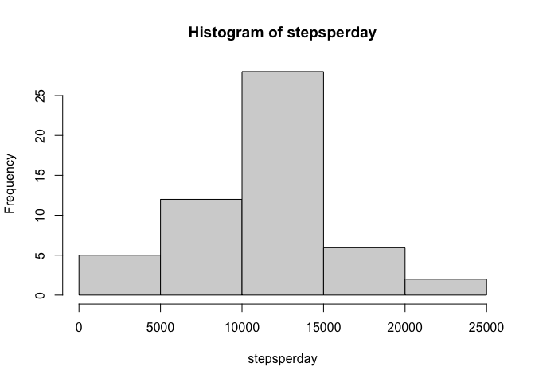

```r
hist(stepsperday)
```

To calculate the mean and median of steps per day.

```r
meanwna <- mean(stepsperday, na.rm=TRUE)
medianwna <- median(stepsperday, na.rm=TRUE)
```

Mean is 1.0766189^{4} and median 10765.

## What is the average daily activity pattern?

Calculate the average steps per interval for all days, and visualize it in line chart.

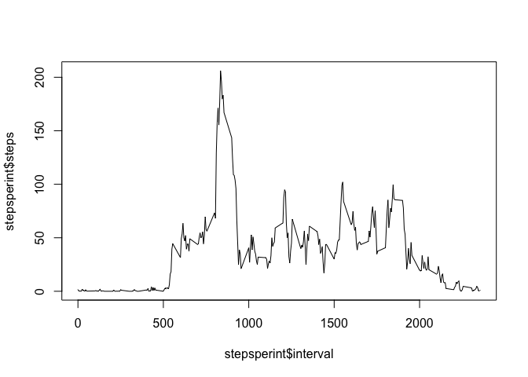

```r
stepsperint <- aggregate(steps ~ interval, data=activity, FUN=mean, na.rm=FALSE)
plot(stepsperint$interval, stepsperint$steps, type="l")
```

```r
maxintstep <- max(stepsperint$steps)
maxint <- stepsperint$interval[which.max(stepsperint$steps)]
```

Max steps of Interval is 206.1698113 and the Interval is 835.

## Imputing missing values

NAs are only existing in the column of steps, the total number of missing value is as below.

```r
colSums(is.na(activity))
```

```
##    steps     date interval
##     2304        0        0
```

Create new object called activitynona by copy it from acrivity object and fill the NA value in the steps columns with rest of the average acrity for all data.

```r
activitynona <- activity
activitynona[is.na(activitynona)] <- mean(activity$steps, na.rm=TRUE)
colSums(is.na(activitynona))
```

```
##    steps     date interval
##        0        0        0
```

After filling NAs, recreate the histgram of steps per day.

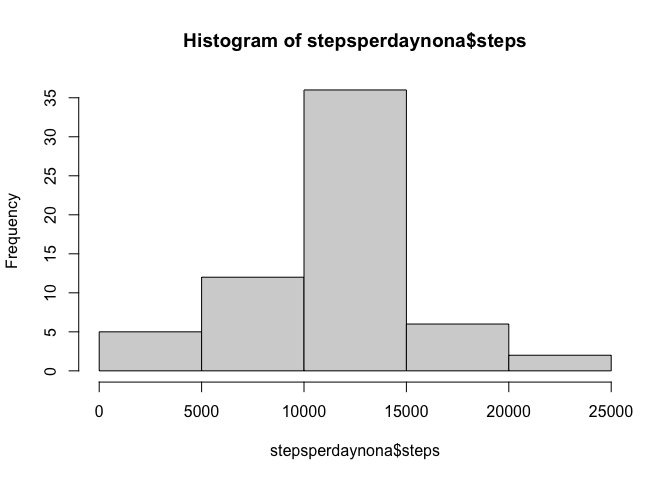

```r
stepsperdaynona <- aggregate(steps ~ date, data=activitynona, sum)
hist(stepsperdaynona$steps)
```

```r
meannona <- mean(stepsperdaynona$steps, na.rm=TRUE)
mediannona <- median(stepsperdaynona$steps, na.rm=TRUE)
```

Even after filling the NAs with average(steps) the mean and median of steps per day will no change a lot.

New mean is 1.0766189^{4} and it was 1.0766189^{4}.

New Median is 1.0766189^{4} and it was 10765.

## Are there differences in activity patterns between weekdays and weekends?

First add new factor valuable on the data set called weekendflag.

```r
library(dplyr)
```

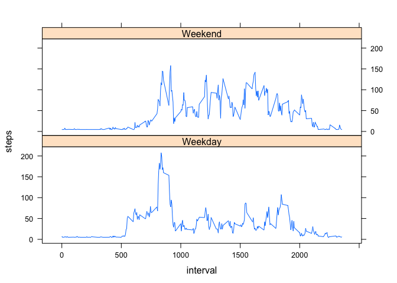

```r
activitynona <- mutate(activitynona, weekendflag = ifelse(weekdays(strptime(activitynona$date, "%Y-%m-%d")) %in% c("日曜日","土曜日"), "Weekend","Weekday"))
stepsweekofday <- aggregate(steps ~ interval + weekendflag, activitynona, mean)
library(lattice)
xyplot(steps ~ interval | weekendflag, stepsweekofday, type='l', layout=c(1,2))
```